# Crossword

Abstract

“Crossword” published in R News.

Following a conversation with 1 down at DSC 2003 post-conference dinner, I have constructed a crossword for R-news. Most of the clues are based on matters relating to R or computing in general. The clues are ‘cryptic’, in that they rely on word-play, but most will contain a definition somewhere. A prize of EUR50 is on offer. See http://www.maths.lancs.ac.uk/~rowlings/Crossword for details.

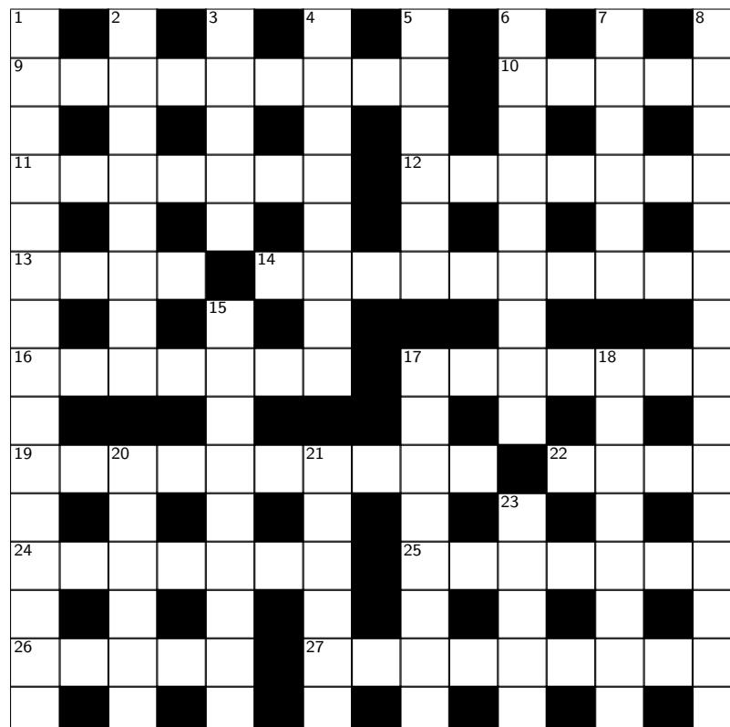

## Across

- 9 Possessing a file, or boat, we hear (9)  
  10, 20 down Developer code is binary peril (5,6)  
  11 Maturer code has no need for this (7)  
  12 And a volcano implodes moderately slowly (7)  
  13 Partly not an hyperbolic function (4)  
  14 Give 500 euro to R Foundation, then stir your café Breton (10)  
  16 Catches crooked parents (7)  
  17, 23 down Developer code bloated Gauss (7,5)  
  19 Fast header code is re-entrant (6-4)  
  22, 4 down Developer makes toilet compartments (4,8)  
  24 Former docks ship files (7)  
  25 Analysis of a skinned banana and eggs (2,5)  
  26 Rearrange array or a hairstyle (5)  
  27 Atomic number 13 is a component (9)

## Down

- 1 Scots king goes with lady president (6,9)  
  2 Assemble rain tent for private space (8)  
  3 Output sounds sound (5)  
  4 See 22ac  
  5 Climb tree to get new software (6)  
  6 Naughty number could be 8 down (1,3,5)  
  7 Failed or applied ! (3,3)  
  8 International body member is ordered back before baker, but can’t be shown (15)  
  15 I hear you consort with a skeleton, having rows (9)  
  17 Left dead encrypted file in zip archive (8)  
  18 Guards riot, loot souk (8)  
  20 See 10ac  
  21 A computer sets my puzzle (6)  
  23 See 17ac